# R Notebook

## Libraries

```r
library(tidyverse)
```

## Spatial analysis

### Learning outcomes

- Know what spatial data is and how it is represented in R
- Know how to plot basic spatial vectors
- Know how to create maps with ggplot
- Understand how to make interactive spatial maps with leaflet

Simple features

Each row in a spatial dataframe / tibble is a feature

```r
library(rnaturalearthdata)
```

{sf} - Stands for simple features - Simple means certain geometries are represented by points that don’t self-intersect (we don’t need to worry about this).

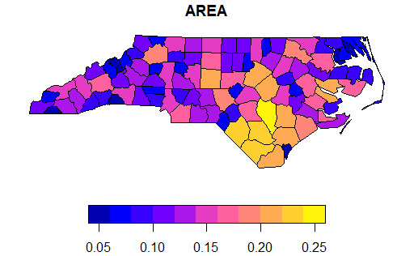

```r
names(north_carolina)
```

```
 [1] "AREA"      "PERIMETER" "CNTY_"     "CNTY_ID"   "NAME"      "FIPS"      "FIPSNO"    "CRESS_ID"
 [9] "BIR74"     "SID74"     "NWBIR74"   "BIR79"     "SID79"     "NWBIR79"   "geometry"
```

```r
nc_geo[[1]]
```

```
MULTIPOLYGON (((-81.47276 36.23436, -81.54084 36.27251, -81.56198 36.27359, -81.63306 36.34069, -81.74107 36.39178, -81.69828 36.47178, -81.7028 36.51934, -81.67 36.58965, -81.3453 36.57286, -81.34754 36.53791, -81.32478 36.51368, -81.31332 36.4807, -81.26624 36.43721, -81.26284 36.40504, -81.24069 …
```

^Output from above consists of: INSTRUCTION ((co-ordinates)) MULTIPOLYGON (((-81.47276 36.23436, -81.54084 36.27251, -81.56198 36.27359, -81.63306 36.34069, -81.74107 36.39178, -81.69828 36.47178, -81.7028 36.51934, -81.67 36.58965, -81.3453 36.57286, -81.34754 36.53791, -81.32478 36.51368, -81.31332 36.4807, -81.26624 36.43721, -81.26284 36.40504, -81.24069 36.37942, -81.23989 36.36536, -81.26424 36.35241, -81.32899 36.3635, -81.36137 36.35316, -81.36569 36.33905, -81.35413 36.29972, -81.36745 36.2787, -81.40639 36.28505, -81.41233 36.26729, -81.43104 36.26072, -81.45289 36.23959, -81.47276 36.23436)))

The “big seven” shapes that a feature can be: 1. POINT (1 1) 2. MULTIPOINT ((1 1), (2 2)) 3. LINE (1 1, 1 2) 4. MULTILINE ((1 1, 1 2), (2 2, 3 3)) 5. POLYGON (1 1, 1 2, 2 2, 2 1, 1 1) - has to close so the first coordinate must match the last coordinate 6. MULTIPOLYGON ((1 1, 1 2, 2 2, 2 1, 1 1)) 7. GEOMETRY COLLECTION (POINT (1 1), MULTILINE((1 1, 1 2), (2 2, 3 3)))

Geometry collection can be made up of multiple shape instructions, and any number of them, just not a geometry collection

Multipolygons are useful when one place is made up of lots of different polygons - e.g. shetland is a multipolygon made up of several island polygons

You can plot individual geometries

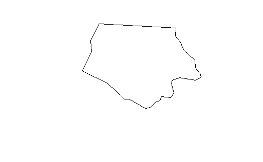

{sf} and {ggplot2}

-with a new geom “geom_sf”

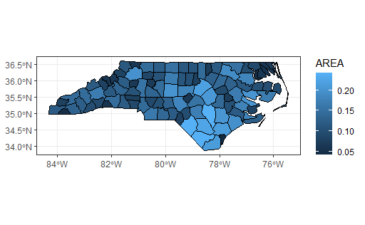

[figure not shown]

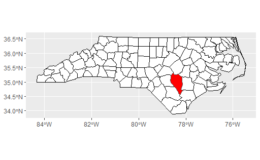

```r
ggplot(north_carolina) +
  geom_sf(fill = "white", colour = "black") +
  geom_sf(data = north_carolina %>%
  filter(AREA == max(AREA)), fill = "red")
```

tsibble –> as_tibble –> tibble sf df –> st_drop_geometry –> df(tibble)

|  | AREA | PERIMETER | CNTY_ | CNTY_ID | NAME | FIPS | FIPSNO | CRESS_ID | BIR74 | SID74 | NWBIR74 | BIR79 | SID79 | NWBIR79 |
| --- | --- | --- | --- | --- | --- | --- | --- | --- | --- | --- | --- | --- | --- | --- |
| 1 | 0.114 | 1.442 | 1825 | 1825 | Ashe | 37009 | 37009 | 5 | 1091 | 1 | 10 | 1364 | 0 | 19 |
| 2 | 0.061 | 1.231 | 1827 | 1827 | Alleghany | 37005 | 37005 | 3 | 487 | 0 | 10 | 542 | 3 | 12 |
| 3 | 0.143 | 1.630 | 1828 | 1828 | Surry | 37171 | 37171 | 86 | 3188 | 5 | 208 | 3616 | 6 | 260 |
| 4 | 0.070 | 2.968 | 1831 | 1831 | Currituck | 37053 | 37053 | 27 | 508 | 1 | 123 | 830 | 2 | 145 |
| 5 | 0.153 | 2.206 | 1832 | 1832 | Northampton | 37131 | 37131 | 66 | 1421 | 9 | 1066 | 1606 | 3 | 1197 |
| 6 | 0.097 | 1.670 | 1833 | 1833 | Hertford | 37091 | 37091 | 46 | 1452 | 7 | 954 | 1838 | 5 | 1237 |
| 7 | 0.062 | 1.547 | 1834 | 1834 | Camden | 37029 | 37029 | 15 | 286 | 0 | 115 | 350 | 2 | 139 |
| 8 | 0.091 | 1.284 | 1835 | 1835 | Gates | 37073 | 37073 | 37 | 420 | 0 | 254 | 594 | 2 | 371 |
| 9 | 0.118 | 1.421 | 1836 | 1836 | Warren | 37185 | 37185 | 93 | 968 | 4 | 748 | 1190 | 2 | 844 |
| 10 | 0.124 | 1.428 | 1837 | 1837 | Stokes | 37169 | 37169 | 85 | 1612 | 1 | 160 | 2038 | 5 | 176 |

[output cut: 90 more lines]

That was NC, how about the world?

241 features (rows) of 64 variables

```r
names(world)
```

```
 [1] "scalerank"  "featurecla" "labelrank"  "sovereignt" "sov_a3"     "adm0_dif"   "level"
 [8] "type"       "admin"      "adm0_a3"    "geou_dif"   "geounit"    "gu_a3"      "su_dif"
[15] "subunit"    "su_a3"      "brk_diff"   "name"       "name_long"  "brk_a3"     "brk_name"
[22] "brk_group"  "abbrev"     "postal"     "formal_en"  "formal_fr"  "note_adm0"  "note_brk"
[29] "name_sort"  "name_alt"   "mapcolor7"  "mapcolor8"  "mapcolor9"  "mapcolor13" "pop_est"
[36] "gdp_md_est" "pop_year"   "lastcensus" "gdp_year"   "economy"    "income_grp" "wikipedia"
[43] "fips_10"    "iso_a2"     "iso_a3"     "iso_n3"     "un_a3"      "wb_a2"      "wb_a3"
[50] "woe_id"     "adm0_a3_is" "adm0_a3_us" "adm0_a3_un" "adm0_a3_wb" "continent"  "region_un"
[57] "subregion"  "region_wb"  "name_len"   "long_len"   "abbrev_len" "tiny"       "homepart"
[64] "geometry"
```

|  | scalerank | featurecla | labelrank | sovereignt | sov_a3 | adm0_dif | level | type | admin | adm0_a3 | geou_dif | geounit | gu_a3 | su_dif | subunit | su_a3 | brk_diff | name | name_long | brk_a3 | brk_name | brk_group | abbrev | postal | formal_en | formal_fr | note_adm0 | note_brk | name_sort | … |
| --- | --- | --- | --- | --- | --- | --- | --- | --- | --- | --- | --- | --- | --- | --- | --- | --- | --- | --- | --- | --- | --- | --- | --- | --- | --- | --- | --- | --- | --- | --- |
| 0 | 3 | Admin-0 country | 5 | Netherlands | NL1 | 1 | 2 | Country | Aruba | ABW | 0 | Aruba | ABW | 0 | Aruba | ABW | 0 | Aruba | Aruba | ABW | Aruba | NA | Aruba | AW | Aruba | NA | Neth. | NA | Aruba | … |
| 1 | 1 | Admin-0 country | 3 | Afghanistan | AFG | 0 | 2 | Sovereign country | Afghanistan | AFG | 0 | Afghanistan | AFG | 0 | Afghanistan | AFG | 0 | Afghanistan | Afghanistan | AFG | Afghanistan | NA | Afg. | AF | Islamic State of Afghanistan | NA | NA | NA | Afghanistan | … |
| 2 | 1 | Admin-0 country | 3 | Angola | AGO | 0 | 2 | Sovereign country | Angola | AGO | 0 | Angola | AGO | 0 | Angola | AGO | 0 | Angola | Angola | AGO | Angola | NA | Ang. | AO | People's Republic of Angola | NA | NA | NA | Angola | … |
| 3 | 1 | Admin-0 country | 6 | United Kingdom | GB1 | 1 | 2 | Dependency | Anguilla | AIA | 0 | Anguilla | AIA | 0 | Anguilla | AIA | 0 | Anguilla | Anguilla | AIA | Anguilla | NA | Ang. | AI | NA | NA | U.K. | NA | Anguilla | … |
| 4 | 1 | Admin-0 country | 6 | Albania | ALB | 0 | 2 | Sovereign country | Albania | ALB | 0 | Albania | ALB | 0 | Albania | ALB | 0 | Albania | Albania | ALB | Albania | NA | Alb. | AL | Republic of Albania | NA | NA | NA | Albania | … |
| 5 | 3 | Admin-0 country | 6 | Finland | FI1 | 1 | 2 | Country | Aland | ALD | 0 | Aland | ALD | 0 | Aland | ALD | 0 | Aland | Aland Islands | ALD | Aland | NA | Aland | AI | Åland Islands | NA | Fin. | NA | Aland | … |

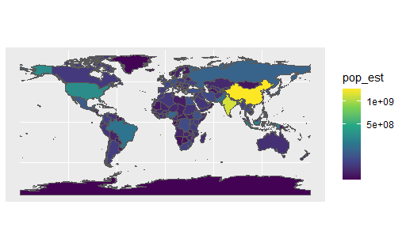

one thing we can do to “better” bisualise the different populations between countries is –> apply a transformation

(india and china are still the most populated countries, but because we reduce how much more populated they are in comparison with the other countries, then we can see other population differences more clearly) Before, because India and China were so much more populated than other countries, the only pop differences that were showing up were really between India and China vs the rest of the world.

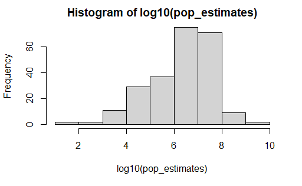

```r
max(pop_estimates, na.rm = TRUE)
```

```
[1] 1338612970
```

highest pop value in the data 1338612970

5500000

Task - 5 mins Recap your knowledge from ggplot week, and set your geom_sf aesthetic to be filled with the estimated gdp (gdp_md_est variable). Extra points if you make your map colour blind friendly! What does your plot tell you? What does it tell you compared to the population?

other variables that are interesting - economy - income group - gdp year

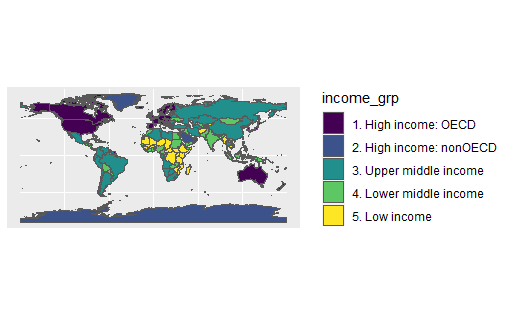

```r
ggplot(world) +
  geom_sf(aes(fill = income_grp), size = 0.7) +
  scale_fill_viridis_d()
```

It tells us that the most populous countries are not necessarily the richest countries.

I wouldn’t have expected Antarctica to be a high income country?

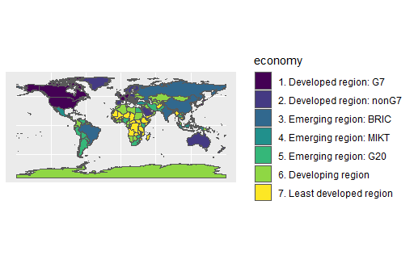

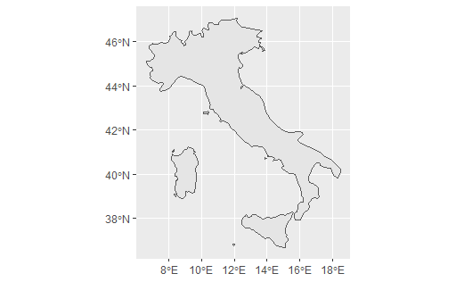

Zooming in on particular areas

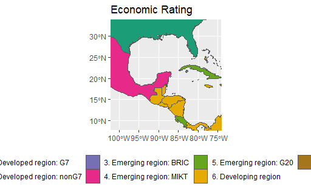

```r
world %>%
  ggplot() +
  geom_sf(aes(fill = economy), size = 0.1) +
  coord_sf(xlim = c(-102.15, -74.12), ylim = c(7.65, 33.9), expand = FALSE) +
  scale_fill_brewer(palette = "Dark2") +
  ggtitle("Economic Rating") +
  theme(legend.position = "bottom")
```

By default coord_sf will give you a slightly larger box than requested, you can turn this behaviour off with expand = FALSE

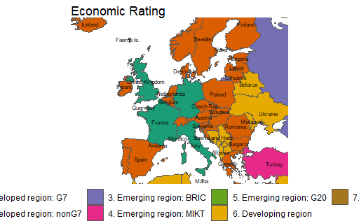

```r
world %>%
  ggplot() +
  geom_sf(aes(fill = economy), size = 0.1) +
  #if you don't set expand to FALSE, it will add a little extra rounding with the coordinates
  coord_sf(xlim = c(-23.9, 39.4), ylim = c(35.3, 66.1), expand = FALSE) +
  #This will place the name in the centre
  geom_sf_text(aes(label = name), size = 2, check_overlap = TRUE) +
  scale_fill_brewer(palette = "Dark2") +
  theme_void() +
  ggtitle("Economic Rating") +
  theme(legend.position = "bottom")
```

Creating Interactive Geospatial Data Visualisations with Leaflet

Individual markers

[interactive chart not shown]

Circle markers

```r
library(jsonlite)
data_url <- "https://data.colorado.gov/resource/j5pc-4t32.json?&county=BOULDER"

water_data <- fromJSON(data_url) %>%
  jsonlite::flatten(recursive = TRUE)
```

Data preparation

amount, latitude and longitude are not numeric data types but they should be

```r
water_clean <- water_data %>%
  mutate(across(
    c(amount, location.latitude, location.longitude), as.numeric
  )) %>%
  filter(!is.na(location.latitude))
```

```r
leaflet(water_clean) %>%
  #add Tiles adds the base map
  addTiles() %>%
  addCircles(
    #in this case the ~ is delaying execution of this sligtly so we don't get a not found error
    lng = ~location.longitude,
    lat = ~location.latitude,
    #makes the size of the circle depend on amount of water at that location
    radius = ~amount/10,
    #create data dependent popups
    popup = ~as.character(amount)
  )
```

[interactive chart not shown]

### Clustering

Popups need to be characters

[interactive chart not shown]

## Simplifying Shapes

[figure not shown]

```r
lengths(nc_geo)

plot(nc_geo[[4]])
```

[figure not shown]

Simplify - increasing the tolerance will decrease the number of points to express that polygon

By simplifying, we can reduce computational runtime(an important resource in shiny apps)

```r
north_carolina %>%
  st_simplify(dTolerance = 2000) %>%
  ggplot() +
  geom_sf() +
  theme_void()
```

## Reading/Writing Shapefiles

```r
#not standard to read in a system file
st_read(system_file())
```

```r
  north_carolina %>%
  st_simplify(dTolerance = 2000) %>%
  st_write(dsn = "nc_simplified", layer = "simple_north_carolina",
           driver = "ESRI Shapefile")
```

```
Writing layer `simple_north_carolina' to data source `nc_simplified' using driver `ESRI Shapefile'
Writing 100 features with 14 fields and geometry type Multi Polygon.
```

shapefiles -.shp -.shx -.prj -.dbf

Usual way we read in shapefiles:

```r
north_carolina_simple <- st_read(dsn = "nc_simplified/simple_north_carolina.dbf")
```

## Leaflet Polygons

```r
pal <- colorBin("Purples", north_carolina_simple$NWBIR74, n = 5)

labels <- paste("<b>", north_carolina_simple$NAME, "</b>", "<br>",
                north_carolina_simple$NWBIR74) %>% lapply(htmltools::HTML)

leaflet(north_carolina_simple) %>%
  addTiles() %>%
  addPolygons(weight = 1, color = "black", fillColor = ~pal(NWBIR74),
              fillOpacity = 100,
              label = labels) %>%
  addLegend(pal = pal,
            values = ~NWBIR74,
            position = "bottomright")
```

## Leaflet in Shiny

- whisky distilleries map
- CodeClanData::whisky

data %>% 1. transform() leaflet()